# Historial de Comandos

## Introducción

La consola de RStudio incluye una variedad de características que nos permitirán trabajar de forma sencilla y eficiente. Esta tarea analiza estas características. Aprender el uso de estas funciones puede jugar un papel fundamental en la productividad con R.

### Recuperando Comandos

Por otro lado, si deseamos recuperar una lista con los comandos recientes podemos utilizar las teclas **Ctrl+Up** :

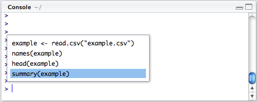

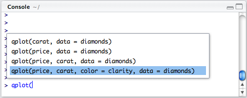

En esta ocasión hemos realizado el ejercicio por ti:

**Ejercicio:** Crea un vector de tipo númerico con los valores 3, 12, 13, 4, 6:

```r
# Creación del vector
v <- c(3, 12, 13, 4, 6)
```

**Ejercicio:**

Calcula la suma de los valores del vector con la función `sum()`:

```r
sum(v)
```

**Ejercicio:** Calcula la media del vector con la función `mean()`:

```r
mean(v)
```

**Pregunta:** Utiliza lo que has aprendido en el video y en la introducción de la tarea para recuperar el comando del historial que calcula la media del vector. ¿Cuál es la media del vector?

**Posibles respuestas:**

5.4

7.6

10.45

12.23

Pista

Desde la consola, utiliza la “flecha arriba” de tu teclado para navegar por el historial de comandos.